# Chapter 6: Supervised Machine Learning

## Key Ideas

Supervised machine learning, label, information gain, feature selection, regression, polynomial degree, overfitting, residuals, root mean squared error (RMSE), time series prediction, random forest, ensemble, artificial neuron, neural network, hidden layers, convolution, convolutional neural network (CNN), deep learning, deep learning algorithm.

# Making Predictions

In **supervised machine learning**, Occam algorithms search for a model. The model is based on a data structure and is capable of predicting a feature’s value. The feature targeted for prediction is called the **label.**

Predicting the label is the goal of a supervised machine learning algorithm. These algorithms are called *supervised* because they require a someone to choose the label.

# Information Gain

The **Information gain** algorithm is an O(n) search for a list of features most predictive of the label.

```r
#grab the air quality data
df.airquality <- as.data.frame(airquality)
#function to check if a package is installed
is_installed <- function(mypkg) is.element(mypkg, installed.packages()[,1])
if(!is_installed("FSelector")){install.packages("FSelector")}
library(FSelector)
#search for features most predictive of temperature
features.scores <- information.gain(Temp~ ., df.airquality)
features.scores
```

```
        attr_importance
Ozone        0.38051966
Solar.R      0.01561183
Wind         0.00000000
Month        0.25896291
Day          0.00000000
```

The algorithm allows us to perform **feature selection** where we filter the data set down to a label and the most predictive features.

```r
#number of features to select
n = 2
#select the top n features
features <- cutoff.k(features.scores, n)
features
```

```
[1] "Ozone" "Month"
```

```r
#filter the data set down to only the top n features
cols <- c(features, "Temp")
df.airquality.filtered <- df.airquality[,cols]
df.airquality.filtered[1:10,]
```

```
   Ozone Month Temp
1     41     5   67
2     36     5   72
3     12     5   74
4     18     5   62
5     NA     5   56
6     28     5   66
7     23     5   65
8     19     5   59
9      8     5   61
10    NA     5   69
```

# Regression

The **Regression** algorithm is an O(n) search for a curve that can be used to predict the label. Use the demonstration below to develop an intuition for the regression algorithm. As you move the observations (points in the space) the curve adjusts to fit. The **polynomial degree** controls the complexity of the curve.

Increasing the polynomial degree allows the model to predict more complicated relationships. But it also creates a model that is less general and less likely to be predictive on new data sets. **Overfitting** is when a model has been overly specialized to fit a particular sample. Cross validation is a standard method for detecting overfitting.

[interactive chart not shown]

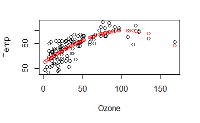

```r
if(!is_installed("mgcv")){install.packages("mgcv")}
library(mgcv)
#remove observations with missing values
df.airquality.complete <- df.airquality.filtered[complete.cases(df.airquality.filtered), ]
#fit a linear model
polynomial_degree = 3
model.linear <-
  lm(df.airquality.complete$Temp ~
       poly(df.airquality.complete$Ozone,polynomial_degree))
#plot the results
plot(Temp~Ozone, data=df.airquality.complete)
points(df.airquality.complete$Ozone, predict(model.linear), col="red")
```

Find the difference between observed and predicted values (**residuals**)

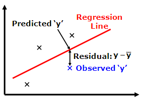

```r
residuals <- residuals(model.linear)
residuals[1:10]
```

```
         1          2          3          4          5          6          7          8
-12.662266  -6.115283   4.370777  -9.900912  -9.471996  -8.721651 -13.270482  -7.065634
         9         10
  6.331086  -2.153879
```

```r
rmse <- mean(sqrt(residuals^2))
print(paste ("The predictions are off by an average of",rmse,"degrees"))
```

```
[1] "The predictions are off by an average of 4.84729443614716 degrees"
```

# Time Series Prediction

A **time series** is a set of observations (ordered by date) with two features: a date and a numeric label. A time series algorithm is a O(n) search for a curve that can be used to predict the label at a future date.

Because a time-series prediction gets less certain further into the future, the confidence interval (shaded in blue below) gets wider.

```r
#time series prediction
#complexity: linear
if(!is_installed("prophet")){install.packages("prophet")}
library("prophet")
#generate a cyclic time series with some randomness added
df.timeseries <- data.frame(
  ds = seq(as.Date('2015-01-01'), as.Date('2016-01-01'), by = 'd'),
  y = sin(1:366/200) + rnorm(366)/10)
#fit a linear model
#complexity: linear
model.timeseries <- prophet(df.timeseries)
```

```
Disabling yearly seasonality. Run prophet with yearly.seasonality=TRUE to override this.
Disabling daily seasonality. Run prophet with daily.seasonality=TRUE to override this.
```

```
Initial log joint probability = -14.174
Optimization terminated normally:
  Convergence detected: relative gradient magnitude is below tolerance
```

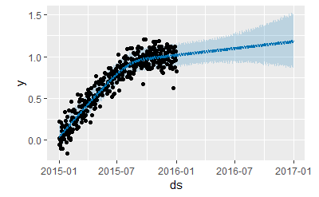

```r
#use the model to predict one year into the future
future <- make_future_dataframe(model.timeseries, periods = 365)
forecast <- predict(model.timeseries, future)
plot(model.timeseries, forecast)
```

# Decision Tree

A **decision tree** algorithm is an O(logN) search for a tree that predicts a label using patterns of relationships among features. The leaves of the tree represent label predictions. The paths leading to each leaf describes the conditions under which we can expect each prediction.

The following decision tree predicts iris species. It predicts that an iris with a petal length less than 1.9 centimeters will be in the setosa species. It predicts that an iris with a petal length greater than 1.9 centimeters and a petal width greater than 1.7 centimeters will be in the virginica species.

```r
#access iris data
df.iris <- as.data.frame(iris)
#split the data into training and test sets
set.seed(1234)
ind <- sample(2, nrow(df.iris), replace=TRUE, prob=c(0.7, 0.3))
df.iris.training <- df.iris[ind==1,]
df.iris.test <- df.iris[ind==2,]
#build a decision tree and use it to predict
#complexity: logarithmic
if(!is_installed("party")){install.packages("party")}
library(party)
formula <- Species ~ Sepal.Length + Sepal.Width + Petal.Length + Petal.Width
iris_ctree <- ctree(formula, data=df.iris.training, controls = ctree_control(maxdepth = 3))
#check the prediction
table(predict(iris_ctree), df.iris.training$Species)
```

```
             setosa versicolor virginica
  setosa         40          0         0
  versicolor      0         37         3
  virginica       0          1        31
```

[figure not shown]

```r
#plot the tree
plot(iris_ctree)
```

```r
#predict on test data
iris.predict <- predict(iris_ctree, newdata = df.iris.test)
table(iris.predict, df.iris.test$Species)
```

```
iris.predict setosa versicolor virginica
  setosa         10          0         0
  versicolor      0         12         2
  virginica       0          0        14
```

# Random Forest

A **random forest** algorithm is an O(logN) search for an collection (or **ensemble**) of decision trees. The algorithm creates decision trees from random samples of the observations. The final prediction is the result of votes from each randomly generated tree. The algorithm works based on the wisdom of crowds where an aggregation of amateure opinions may predict better than a single expert.

```r
if(!is_installed("randomForest")){install.packages("randomForest")}
library(randomForest)
#train N decision trees from N random samples and predict based on the majority outcome
#complexity: logarithmic
rf.iris <- randomForest(Species ~ ., data=df.iris.training, ntree=100)
rf.iris.predict <- predict(rf.iris, newdata = df.iris.test)
table(rf.iris.predict, df.iris.test$Species)
```

```
rf.iris.predict setosa versicolor virginica
     setosa         10          0         0
     versicolor      0         12         2
     virginica       0          0        14
```

# Neural Networks

An **artificial neuron** is a function that takes in parameter values between 0 and 1 and returns an output between 0 and 1. A **neural network** is a network of artificial neurons. Neurons are connected so that the output of one becomes the input of another.

The network is structured into layers of neurons. The first layer is designed to encode information from the real world. The last layer is designed to decode that information into a description of the real world. For example, the first layer of a neural network encodes an image of a human face. The last layer of the neural network categorizes the image as a human face. Each neuron in the last layer corresponds to a predicted outcome (it’s a human face, it’s a chair, it’s a cloud, etc.). The output of each neuron represents the confidence in a particular outcome (0.5 confident that it’s a face, 0.2 confident that it’s a chair, 0.7 confident that it’s a cloud, etc.)

The layers between the first and last are known as the **hidden layers**. The hidden layers break the input into patterns and make it possible to map different input to the same category, even though the inputs may vary. For example, the hidden layers make it possible to recognize two different images as faces even though the person is smiling in one image and frowning in another.

A **convolution** is when we abstract an input based on a particular concept. For example, we can represent a face as a series of lines. A **convolutional neural network (CNN)** abstracts the input before encoding it into the network. Convolutional pre-processing makes it easier for the network to recognize patterns. **Deep learning** is when we build an neural network on several layers of convolutional abstractions.

[interactive chart not shown]

The first layer of a neural network encodes the features of a data set. The last layer corresponds to the confidence (a number between 0 and 1) in the match between the input and each level of a factor label.

```r
if(!is_installed("h2o")){install.packages("h2o")}
library(h2o)
#start an h2o cluster capable of hosting the neural network
all_available_cores = -1
h2o.init(nthreads = all_available_cores)
```

[output not shown]

```r
#get a training set of hand-written digit images
images.train.file <- "https://h2o-public-test-data.s3.amazonaws.com/bigdata/laptop/mnist/train.csv.gz"
images.train <- h2o.importFile(images.train.file)
#get a test set of hand-written digit images
images.test.file <- "https://h2o-public-test-data.s3.amazonaws.com/bigdata/laptop/mnist/test.csv.gz"
images.test <- h2o.importFile(images.test.file)
#specify the data set's features and the label
y <- "C785"
x <- setdiff(names(images.train),y)
#encode the label as a factor
images.train[,y] <- as.factor(images.train[,y])
images.test[,y] <- as.factor(images.test[,y])
#train a deep learning model on the training set and validate it on the test set
model <- h2o.deeplearning(x=x,y=y,training_frame = images.train, validation_frame = images.test)
```

The perfect neural network will, for example, take an image of a human face and predict with confidence of 1 that the image is a human face. For those images that are not human faces, it would predict with confidence 0 that the image is a face.

The RMSE for a neural network is the average difference between the actual and ideal confidence of a neural network.

```r
#Get the RMSE
mse <- h2o.mse(model, valid = TRUE)
rmse <- sqrt(mse)
print(paste("On average, the prediction confidence of the model is off by", rmse))
```

```
[1] "On average, the prediction confidence of the model is off by 0.174467532030295"
```

# Imputing Data

We can fill in missing observation features ( **impute data**) by using supervised machine learning algorithms to predict the missing values. When imputing data, the label is the feature with missing.

Imputing missing data

```r
#impute missing data
summary(df.airquality)
```

```
     Ozone           Solar.R           Wind             Temp           Month
 Min.   :  1.00   Min.   :  7.0   Min.   : 1.700   Min.   :56.00   Min.   :5.000
 1st Qu.: 18.00   1st Qu.:115.8   1st Qu.: 7.400   1st Qu.:72.00   1st Qu.:6.000
 Median : 31.50   Median :205.0   Median : 9.700   Median :79.00   Median :7.000
 Mean   : 42.13   Mean   :185.9   Mean   : 9.958   Mean   :77.88   Mean   :6.993
 3rd Qu.: 63.25   3rd Qu.:258.8   3rd Qu.:11.500   3rd Qu.:85.00   3rd Qu.:8.000
 Max.   :168.00   Max.   :334.0   Max.   :20.700   Max.   :97.00   Max.   :9.000
 NA's   :37       NA's   :7
      Day
 Min.   : 1.0
 1st Qu.: 8.0
 Median :16.0
 Mean   :15.8
 3rd Qu.:23.0
 Max.   :31.0
```

```r
if(!is_installed("mice")){install.packages("mice")}
library(mice)
#review methods for imputing missing data
methods(mice)
```

```
function 'mice' appears not to be S3 generic; found functions that look like S3 methods
```

```
 [1] mice.impute.2l.bin       mice.impute.2l.lmer      mice.impute.2l.norm
 [4] mice.impute.2l.pan       mice.impute.2lonly.mean  mice.impute.2lonly.norm
 [7] mice.impute.2lonly.pmm   mice.impute.cart         mice.impute.jomoImpute
[10] mice.impute.lda          mice.impute.logreg       mice.impute.logreg.boot
[13] mice.impute.mean         mice.impute.midastouch   mice.impute.norm
[16] mice.impute.norm.boot    mice.impute.norm.nob     mice.impute.norm.predict
[19] mice.impute.panImpute    mice.impute.passive      mice.impute.pmm
[22] mice.impute.polr         mice.impute.polyreg      mice.impute.quadratic
[25] mice.impute.rf           mice.impute.ri           mice.impute.sample
[28] mice.mids                mice.theme
see '?methods' for accessing help and source code
```

```r
#impute missing air quality data
df.airquality.imputed <- mice(df.airquality,m=5,maxit=50,meth='pmm',seed=500,print = FALSE)
df.airquality.complete <- complete(df.airquality.imputed,1)
summary(df.airquality.complete)
```

```
     Ozone           Solar.R           Wind             Temp           Month
 Min.   :  1.00   Min.   :  7.0   Min.   : 1.700   Min.   :56.00   Min.   :5.000
 1st Qu.: 16.00   1st Qu.:115.0   1st Qu.: 7.400   1st Qu.:72.00   1st Qu.:6.000
 Median : 30.00   Median :212.0   Median : 9.700   Median :79.00   Median :7.000
 Mean   : 40.01   Mean   :187.5   Mean   : 9.958   Mean   :77.88   Mean   :6.993
 3rd Qu.: 59.00   3rd Qu.:259.0   3rd Qu.:11.500   3rd Qu.:85.00   3rd Qu.:8.000
 Max.   :168.00   Max.   :334.0   Max.   :20.700   Max.   :97.00   Max.   :9.000
      Day
 Min.   : 1.0
 1st Qu.: 8.0
 Median :16.0
 Mean   :15.8
 3rd Qu.:23.0
 Max.   :31.0
```